Tholonia - 015-MIND  
The Existential Mechanics of Awareness  
Duncan Stroud  
Published: January 15, 2020  
Updated: Updated: Mar 26, 2026 v8.0.89  
Welkin Wall Publishing  
ISBN-10:  
ISBN-13: 978-1-6780-2532-8  
Copyright ©2020 Duncan Stroud CC BY-NC-SA 4.0

This book is an open sourced book. This means that anyone can contribute changes or updates. Instructions and more information at https://tholonia.github.io/the-book (or contact the author at duncan.stroud@gmail.com). This book and its on-line version are distributed under the terms of the Creative Commons Attribution-Noncommercial-ShareAlike 4.0 International (CC BY-NC-SA 4.0) license, with the additional proviso that the right to publish it on paper for sale or other for-profit use is reserved to Duncan Stroud and authorized agents thereof. A reference copy of this license may be found at https://creativecommons.org/licenses/by-nc-sa/4.0/. The above terms include the following: Attribution - you must give appropriate credit, provide a link to the license, and indicate if changes were made. You may do so in any reasonable manner, but not in any way that suggests the licensor endorses you or your use. Noncommercial - You may not use the material for commercial purposes. Share Alike - If you remix, transform, or build upon the material, you must distribute your contributions under the same license as the original. No additional restrictions - you may not apply legal terms or technological measures that legally restrict others from doing anything the license permits. Notices - You do not have to comply with the license for elements of the material in the public domain or where your use is permitted by an applicable exception or limitation. No warranties are given. The license may not give you all of the permissions necessary for your intended use. For example, other rights such as publicity, privacy, or moral rights may limit how you use the material.

# 15: MIND

###### The universal machine of creation

##### **Synopsis:** Intelligence is a fundamental property of existence, inherent in the Awareness and Intentions that underlie all patterns of energy. Mind arises where archetypal patterns in the tholonic realm achieve sufficient coherence and definition to instantiate into material forms. This process operates through bidirectional entropy flows: the conceptual realm moves from chaos to order (from high to low entropy), while the material realm moves from order toward chaos (low to high entropy). At the interface where these flows meet, concepts become instances. Coherence, consciousness, and intelligence are examined as successive expressions of A&I, from the incoherent expansiveness of primal awareness to the self-organizing patterns of tholonic intelligence. Aggregates of intelligence, panpsychism, and the emerging consciousness of AI are explored within this framework.

##### **Keywords:** coherence, consciousness, intelligence, archetypal patterns, instantiation, entropy flow, tholonic intelligence, aggregates, AI, panpsychism

Chapter 14 demonstrated that the N-D-C pattern is a universal structural constraint, present in circuits and societies, molecules and minds, and closed by asking what it means that the organ through which we perceive and reason is itself a tholon following the same rules as everything else it perceives and reasons about. The answer begins with a concept that sits at the heart of that question: coherence.

## Coherence

We’re going to introduce a new concept here: coherence. Most readers will already have an idea of what that means, but, as with so many words, it can mean different things in different contexts. Let’s be clear on how it will be used here.

“Coherent” can mean *logically connected*, *consistent*, a *natural connection between parts*, and generally convey the idea of parts that contribute to the whole, i.e., *partons*. This is a fundamental concept of the thologram, with its tholons and partons. In physics, the term “coherent” has a very specific, measurable definition.

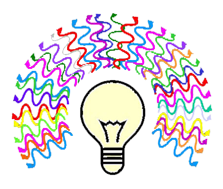

*Incoherent* light is light of every possible wavelength (given the context of the source, such as the Sun or a bulb) that travels in every direction it *can* travel. This is the common form of light we see and use every day. Incoherence is the most fundamental quality of energy, as energy’s nature is to expand in every way and in every direction it can. Using the word *incoherent* to describe the creative and expansive nature of energy is unfortunate as incoherence is synonymous with senseless, disorganized, and meaningless, which could not be further from the truth when it comes to the most efficient distribution of energy in the universe.

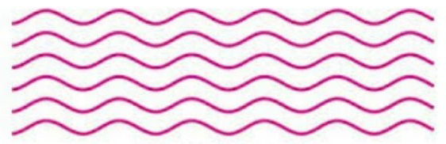

*Coherent* light is when all the waves are of the same wavelength, oscillating in harmony, and all moving in the same direction. Like most things in our space-time reality, there are 2 kinds of coherence: time and space. *Spacial coherence* is when light of any wavelength is traveling in the same direction. *Temporal coherence* is when all the light is only one wavelength but can be traveling in any direction.

Natural sources like the Sun and stars emit light with very low temporal coherence (on the order of femtoseconds) because of their broad thermal spectra. However, they can exhibit spatial coherence at great distances because they appear nearly point-like, which is why stellar interferometry works. True natural sources of coherent light do exist in space in the form of astrophysical masers and megamasers, where stimulated emission in molecular clouds produces narrow-band, coherent microwave radiation, much like natural lasers. These naturally coherent sources demonstrate that coherence can emerge from nature under specific conditions, making laser light less of an anomaly and more of an extreme example of a natural phenomenon.

In practical terms, there can’t actually be a single wavelength of light because wavelength, as a measure, is analog. We can say the wavelength is 555 nm (nanometers), but that still leaves an infinite number of possible wavelengths between 555.0 nm and 555.99999999 nm. Nor can two photons travel the same path, so there is no such thing as perfect coherence, only perfect incoherence.

This relationship between coherence and incoherence mirrors the nature of entropy itself: perfect disorder (maximum entropy, perfect incoherence) is the natural state that systems tend toward, while perfect order (zero entropy, perfect coherence) remains an unattainable ideal that we can only approach through the application of constraints and energy. In tholonic terms, incoherence represents the expansive nature of *Contribution* (high entropy, energy dispersed in all possible ways), while coherence represents the constraining nature of *Definition* (low entropy, energy channeled into specific patterns). Just as a laser creates coherence by imposing constraints through mirrors and selective wavelengths, all forms of order in the Universe emerge through the balance between these two fundamental forces.

This coherence-entropy relationship reveals a profound distinction between material and conceptual realms. In the material world, coherence must be forcibly created and maintained through constraints and energy input. Light naturally disperses into incoherence, and order decays into disorder. But in the conceptual realm, the direction reverses: ideas, formulas, and understanding naturally evolve toward greater coherence and interconnection over time. Scientific theories become more elegant and unified, mathematical expressions simplify yet explain more, and knowledge crystallizes into increasingly coherent frameworks. The conceptual realm naturally moves from chaos toward order (decreasing entropy, increasing coherence), while the material realm naturally moves from order toward chaos (increasing entropy, decreasing coherence). The laser, then, is a material instance that briefly mirrors the conceptual realm’s natural tendency. It represents a forced crystallization of order in a world that naturally disperses.

In tholonic terms, this spectrum has two distinct endpoints, and neither is disorder in the pejorative sense. At the parent end sits the implicit N-state: Definition and Contribution exist as undifferentiated potential, not yet separated or expressed. This is the incoherent pole, not because it is chaotic noise, but because the two tendencies have not yet become distinct. It is pre-structured potential, the tholonic equivalent of the primal A&I before instantiation. At the child end sits the explicit N-state that emerges between the fully expressed D and C of the parent. This is the coherent pole, the point where Definition and Contribution have been completely differentiated and their sustained interaction has resolved into a new balance point. The child N is maximally coherent precisely because D and C are now fully distinguished and held in equilibrium. Coherence, then, is not simply the imposition of constraint; it is the state produced when Definition and Contribution have been fully expressed and their tension has given rise to something new between them.

These two opposing entropy flows must meet at a point, and that point is the moment of instantiation itself, the boundary where concept becomes form, where archetype manifests as instance. This interface represents the highest point of coherence in the entire system, the singular moment where the tholonic realm’s journey toward maximum order intersects with the material realm’s journey toward maximum disorder. A concept, having achieved a state of refined coherence and low entropy in the tholonic realm, crosses this threshold into material instantiation. At the precise moment of crossing, coherence peaks. The concept is maximally defined, maximally ordered, maximally coherent. But the instant it enters material reality, it begins the inevitable entropic journey in the opposite direction, dispersing, decaying, losing coherence as the material realm’s laws take hold. The two realms do not overlap; they meet at a point of coherence. This explains why archetypes remain eternal and unchanging in the conceptual realm, while their material instances are temporary and entropic. The interface itself, this coherence singularity, might be understood as the *white dot* of the tholon (the fourth point of the tetrahedron introduced in Chapter 11, the emergent apex that carries the integrated output of the N-D-C interaction), the point of instantiated power where potential (tholonic coherence) transforms into manifestation (material form), and where the arrow of entropy reverses direction.

To illustrate the scale of coherence: the most coherent beam sent out from our best lasers is 4 miles wide by the time it hits the moon. According to theory, the least divergence we can ever expect to see is 0.000038°.

How is light made more coherent? In a laser, there is a mirror at each end of a gas-filled tube. The gas is zapped with energy, exciting the atoms and causing them to emit photons. Due to the gas’s properties, these photons have a specific wavelength. This is the temporal coherence part of a laser. These photons do what photons naturally do and travel to where they *can* travel, which is pretty limited given they are stuck in a tube.

Some of the photons are lucky enough to hit the mirror, which bounces them to the other mirror, causing them to bounce back and forth forever between the two. As these photons bounce back and forth, they also stimulate other atoms to emit photons that travel in the same direction. This is called the *avalanche effect*, and, as the name implies, soon, all the photons are bouncing back and forth along 1 dimension in both directions, which creates spatial coherence.

It is the interference created by these opposing directions that causes a *standing wave pattern* to form, just like the interference in sounds waves across a 2D surface causes some part of the surface to stay still (where the sand ends up). Other parts to vibrate a lot (where the sand bounces off). Think of the photons as grains of sand, the energy pumped into the tube as vibrations of sound, and the pattern created in the tube as the result of the speed of light and the distance between the two mirrors. One of the mirrors is only 98% reflective, and the other is 100%, so the light that comes out of the laser is the 2% that escapes.

In short, the way to make energy more coherent is to create a sustainable pattern that conserves energy, and soon all the energy will travel along the path of least resistance. The reality we know, with planets, atoms, and laws, is such a multidimensional standing wave pattern. Primal Awareness & Intention is instantiated as the expansion of incoherent energy. Our material Universe is the result of the patterns caused by the various resonances, or “coherences”, of various forms and frequencies of that energy.

If *frequency* = (speed of light)/(wavelength), and *mass* (material reality) = energy/c² where c² represents the space-time metric, both of which are well-established in physics, then by the same reasoning, *instantiations* = (Awareness & Intention)/context. In the tholonic model, energy itself is understood as an instance of Awareness & Intention. At the same time, context represents the limitations imposed on that instance, whether spatial, temporal, or dimensional. Instantiations can be either material (such as matter and energy in space-time) or conceptual (such as ideas and patterns in the tholonic realm). The question then becomes: can this relationship be tested, and if so, how?

## Consciousness

Suppose the concept of a thing and the thing itself are two orders of the same form of expression of energy, and order is a prerequisite to intelligence. Does this imply that everything with order potentially has a form of intelligence? In the tholonic model, yes, but more than that, even without the coherence of order or intelligence, there is the incoherence of A&I.

*Note: More accurately, what we are calling “intelligence” should be called “coherent intelligence” or “low-entropy intelligence”, as intelligence is innate to existence, which includes the chaos that order emerges from and returns to. We can think of that chaotic, incoherent intelligence as “high-entropy intelligence,” but, for simplicity and clarity, when we refer to “intelligence,” we mean coherent, low-entropy intelligence.*

#### **Key 69:** Consciousness is an instantiation of the archetype of Awareness, limited and defined by the scope and context of its instance.

The fact that we tend to understand consciousness through our human perspective prevents us from seeing it as an attribute of existence. Humans may ask, “When did consciousness arise?” but from the tholonic perspective, consciousness is a limited instance of unlimited A&I. A&I is the incoherent source; consciousness is what that source looks like when it has been instantiated through a specific tholonic context, shaped by Definition and Contribution into a particular, bounded form. Because all matter and forms of energy are expressions of A&I at some scope and context, all limited instances of energy are, to that degree, expressions of consciousness.

Everything has consciousness because everything is an instance of Awareness & Intention limited by the context of its instance. The main difference between primal A&I and consciousness is coherence. A&I is incoherent, like the light of the sun, radiating in all frequencies in all directions. Consciousness, being a limited instance of A&I, is naturally more coherent. This makes even the smallest form of matter “conscious” to some degree, as it is coherent enough to be sustainable.

However, the potential for A&I to emerge in simple systems is limited by the number of available microstates. As instances become more complex (which they naturally will because energy always seeks to move through systems), more microstates become available, allowing more emergent expressions of A&I. This complexity increases naturally: quarks form subatomic particles, which form atoms, which form molecules, which form organic compounds, which form life. Each level provides more microstates for energy distribution and balance.

Hence, the consciousness that can emerge from the most complex system we know of in the universe, the human, is significantly more sophisticated, encompassing, and creative than the consciousness of simpler systems like a rock or a chair. This is not because humans have created consciousness, but because the universal attribute of A&I is more fully expressed when more microstates are available.

#### **Key 70:** Matter and consciousness are instances of A&I in a limited context.

Understanding the difference between consciousness and awareness can be tricky because many languages lack distinct words for these two concepts. For our purposes, we define *awareness* as a property of existence and *consciousness* as that same property when expressed through an instantiation, which is a definition or limitation, such as a person or a thing. It is similar to the difference between “dotness” and “a dot” or “movement” and “1968 Chevy Impala”. In a broader sense, it is more practical to think of A&I not as personal attributes an individual develops or possesses, but as a universal attribute an individual expresses. In this way, these attributes are more like gravity: more apparent when there is more mass, not because the mass creates gravity.

So, does a chair have consciousness? Tholonically, yes, but with an important caveat. Consider the evolutionary path of the “chair” concept itself over thousands of years: from a rock used as a seat to a simple stool to increasingly sophisticated designs that require tremendous structure, organization, and order to exist. We can say that, as a chair, the rock has evolved to a much higher form of consciousness, expressing A&I through more complex microstates and relationships.

A modern chair is composed of billions of atoms, each containing tremendous energy that holds the nucleus together. As a holon, the chair provides additional microstates for its partons (wood, metal, springs, screws), and as a parton itself, it provides microstates for its parent holons (house, office, manufacturer). In less material realms, “chair” has profound effects on patterns related to ergonomics, aesthetics, social dynamics, and economics. The chair’s “consciousness” expresses through energy distribution. This happens in the comfort it provides (low resistance, high entropy), and in the tremendous distribution of energy via designers, engineers, and a 14-billion-dollar-a-year industry.

However, it’s not until we reach the level of human complexity that the emergent quality of self-awareness becomes apparent. Self-awareness requires not just consciousness (coherent A&I) but sufficient complexity and microstates for the system to model itself within itself. This is the distinction between the consciousness of a chair and the consciousness of a human.

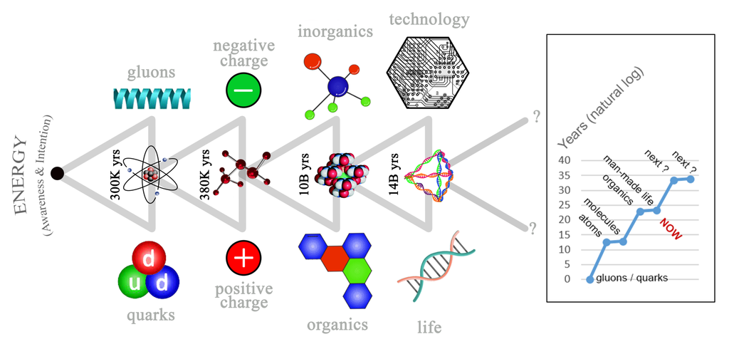

Consciousness, as we humans understand it, is how A&I expresses itself in the macrostate of “human”, just as *heat* is how A&I expresses itself in the macrostate of *atoms*. Heat is the most fundamental expression of A&I. The Universe exists because of heat, and no part of the Universe is absent from it. In fact, “no heat” is a good definition of *nothingness*. As the next evolutionary phase emerges, instances of A&I will be as different from what we currently understand as “consciousness” as that concept is to heat.

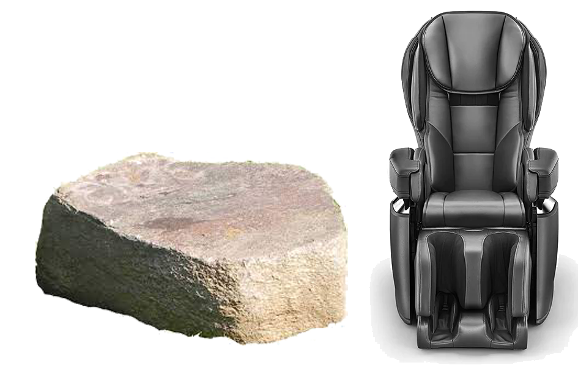

The chair example illustrates this progression beautifully. From rock to modern ergonomic chair, we see consciousness evolving through increasing complexity, structure, and energy distribution. Yet even this sophisticated chair lacks self-awareness, that emergent property that appears only at the level of biological complexity represented by brains with highly patterned structures allowing abstract thought and self-modeling.

This suggests that while heat is the expression of A&I in atoms, it is the problem-solving abilities of intelligence that are the expression of A&I in higher orders. We would call this *creative thinking*, but tholonically, it is *problem-solving* because as far as energy is concerned, the only “problem” that exists is how to distribute itself better.

The idea that A&I, and the intelligence that emerges from it, is a property of existence is not that radical, as many great thinkers in the past have come to a similar conclusion.

> There is a quality of life and intelligence to all matter. The living universe. **~Giordano Bruno (1548-1600), cosmological theorist, philosopher, mathematician & poet burned at the stake for heresy.**

> Crystals are living beings at the beginning of creation. In crystals, we have clear evidence of a formative life principle, yet we cannot understand their life; they are still living beings. **~Nikola Tesla**

> The Universe has been set up in an exquisitely specific way so that evolution could produce the people that are sitting here today, and we could use our intelligence to talk about the universe. **~Ray Kurzweil, Director of Engineering at Google, predictor of the technological singularity.**

> My religion consists of a humble admiration of the illimitable superior spirit who reveals himself in the slight details we can perceive with our frail and feeble minds. That deeply emotional conviction of the presence of a superior reasoning power, which is revealed in the incomprehensible Universe, forms my idea of God. **~Albert Einstein**

We are all familiar with the ideas of a universal, omniscient, omnipresent intelligence and awareness, as these are the qualities we assign to the concept of God. This is not to say that God does or does not exist. That is a question left to others, but regardless of the answer, the tholonic claim is that these god-like properties *are* innate to creation and all that exists.

The reader may be thinking, “Well, I have awareness and intention, so can I just start creating realities?” and the answer would be “yes”, especially if the reader has 10<sup>68</sup> joules of A&I to spare. What’s that? Don’t have enough energy to create a Big Bang just by the power of your awareness? How much energy *do* you have?

Consider that those 10<sup>68</sup> joules were spread out across 10<sup>82</sup> atoms, minus the 10<sup>55</sup> joules used up by radio waves over the lifetime of the galaxy, and the 10<sup>52</sup> joules used up by the rotation of the Milky Way, and countless other things in the Universe that use energy. We humans, have only a paltry amount of energy to spare, so paltry that the entire energy consumption of the part of our brain that enables human meta-consciousness is less than 1 watt[^1]. That light of self-awareness is a small LED.

The miracle of meta-consciousness, the awareness of our awareness and our intentions, and that which has allowed humans to understand reality and the Universe (to the degree we do) depends on how much energy our brain has access to, which translates to calories, which means food. Our genius is greatly because our primate ancestors discovered cooking, as cooked food requires less energy to digest, thereby providing a bit more juice to our dim 1-watt powered cerebral cortex[^2].

So, maybe you can’t create your own personal 1-watt Universe, but 300 people who coherently focus their A&I is 300 watts. If that 300 watts were in the form of coherent light, it could, as a comparison, cut through metal (though human A&I operates quite differently from coherent light). Imagine if all humans were to work as one, there would be 8 billion watts of coherent energy available; not enough for a Big Bang, but more than enough to reshape reality in our little corner of the Universe.

It may seem odd to mix our ideas about energy and awareness; after all, what does a chair have to do with consciousness? Looking at energy from a deeper, broader perspective shows that the difference between a chair and a human is simply a (huge) difference in context, resources, and order. For more, see the “*A&I*” section in the chapter on “*Experiments*”.

There is a name for the idea that consciousness is a property of existence; *panpsychism*. You can read about its long history[^3] and the impressive support it has received over the last 2,000 years from some of the greats of philosophy, psychology, and science. The minor difference between panpsychism and tholonism is that the latter claims it is A&I, not consciousness, that created reality, of which consciousness and intelligence are a product.

## Intelligence

This topic of *intelligence* alone has filled, and will continue to fill, countless volumes of speculation, research, and definition. For our purposes, we define intelligence as the ability to “learn and plan using reason and creativity”. That’s quite a broad definition, but it applies to the vast and varied instances of intelligence.

The context of an instance of intelligence determines how these qualities are expressed, and context is determined by the interactions and integration of anything with its environment, or that which it depends on and that which depends on it. We can clearly see these different instances of intelligence among “intelligent species” across cultures and time.

Current thinking has broadened our concepts of intelligence with qualifiers such as left-brain, right-brain, collective, fluid, etc., and the more traditional qualifiers of visual, auditory, and kinesthetic have been expanded to verbal, logical, spatial, musical, interpersonal, intrapersonal, naturalist, existential, and more[^4]. The concept of reasoning, therefore, is also qualified: left-brain reasoning, right-brain reasoning, collective reasoning, logical reasoning, etc.

There is no prerequisite of meta-consciousness, or self-awareness, for intelligence to exist. Meta-consciousness is a context for intelligence but not the cause. In all cases, instances of intelligence are products of the applicable context. This is why we see rather phenomenal *swarm intelligence* in not only living systems like ants, bees, and plants, as well as humans[^5], but in any decentralized, self-organizing system, natural or artificial, including A.I.[^6]. This is compatible with the tholonic concept of intelligence, which is:

#### **Key 71:** Intelligence exists in anything with a sustainable energy pattern.

So, intelligence in this context does not mean “critical thinking” or “self-awareness.” Still, it means creativity, learning, and problem-solving, which are qualities that nature and the Universe demonstrate with flying colors. We can further claim that the amazing relationships in simple geometry, such as the tetrahedron array with its Fibonacci numbers, ratios, and hexagonal patterns that define the laws of nature and reality, are evidence of logic. So, let’s add *logic* to the list of properties.

For the record, the tholonic definition of “logic” is quite close to the traditional *informal* definition (as opposed to the *formal*, *extended*, *lexical*, *stipulative*, *persuasive*, *parenthetical*, *sentence*, *intention*, *ostensive*, *symbolic*, *mathematical*, and other classifications of definitions for the word)

#### **Key 72:** “Logic” is a model based on cause and effect that requires justification that adheres to laws based on observable reality.

What about *planning*? Does nature plan anything, or do we all happen to live in a corner of the Universe that was lucky enough to win the Cosmic Mega-Lotto? We can easily see that simple relationships among 3 points instantly define an infinite array of order, pattern, and symmetry at many levels. This isn’t just logic; it is *the* logic upon which existence is built.

Is there creativity in the Universe? Only if one considers all of creation an act of creativity. Does the Universe learn? Have things evolved over the past 14 billion years by building on an ever-growing, decentralized, self-organizing foundational structure? If the answer is “yes”, we’ll add *learning* to the list.

Here, it is worth clarifying an earlier point. When we speak of the Universe having a “plan,” we are not invoking Intelligent Design in any anthropomorphic sense, but rather recognizing a coherent pattern that evolves through the tholonic realm based solely on the movement of energy. The architecture of universal evolution exists primarily as a conceptual structure, a pattern residing in the realm where entropy naturally decreases over time. Just as the concept of “chair” has evolved from a rock used for sitting to the ergonomically perfected Herman Miller Aeron, moving from crude functionality toward refined coherence, so too does the conceptual architecture of the Universe evolve. This evolution traces a path from the infinite chaos of the primordial singularity (the infinite point of gravity at the Big Bang) toward what will ultimately become an infinitely interconnected network of relationships, the final pattern of reality where all things connect to all things in perfect order. Paradoxically, this ultimate state of conceptual coherence and order in the tholonic realm instantiates in the material realm as the heat death of the Universe, where maximum material entropy represents the completion of energy’s journey toward perfect distribution. The two realms move in opposite entropic directions: concepts evolve toward maximum coherence (minimum entropy) while their material instantiations evolve toward maximum distribution (maximum entropy). The Universe’s “plan” is thus not a blueprint imposed from outside, but an inherent trajectory encoded in the bidirectional nature of entropy itself, the inevitable arc from primordial unity through creative differentiation to ultimate integration.

What about problem-solving? This is a trick question because there is no such thing as a “problem” from the perspective of existence. After all, as we have covered, if something does not follow the laws, it does not exist. If it does follow the laws, it does exist, so where’s the problem as far as the Universe is concerned?

“Problems” appear to be a concept born in the meta-awareness of more developed life forms and are more like *requirements of integration*. Still, the fact that existence is only afforded to that which follows the laws suggests that this is damn good preemptive problem-solving, as it prevents “problems” from ever happening in the first place.

Beyond this “it’s all good” perspective, when conflicting forces come into contact, negotiation and/or conflict occur until a stable state is reached. If both forces end up destroyed in achieving stability, that’s not a “problem”; it’s a “solution”.

All the boxes have been checked:

creativity learning problem-solving logic/structure planning.

A real-world example of such intelligence can be found in what is called *intelligent polymers*, or *smart polymers*, such as *intelligent hydrogel (IH)*. IH is a “gel” that has the “*ability to change their mechanical properties, swelling ability, hydrophilicity, bioactive molecules permeability, etc., influenced by various stimuli, such as temperature, pH, electromagnetic radiation, magnetic field, and biological factors.*”[^7] It “*can perceive small physical/chemical stimuli (such as temperature, light, magnetism, pH) and make significant response behaviors*.”[^8] IHs are intelligent enough to self-assemble and self-order themselves from a state of chaos to make their systems more energy efficient[^9].

IH is currently used in *tissue engineering* to repair retinas, ligaments, fats, blood vessels, etc., and in drug delivery systems (DDSs). Given that graphene is a very tholonic material, it is not surprising that graphene-based hydrogels are “intelligent” and are being used in advanced pharmaceutical delivery systems. In the past couple of years, IHs have been developed that can self-assemble into bio-circuits and even DNA.

As ideas are expressions of energy that incorporate and are even defined by the properties of intelligence listed above, it’s reasonable to conclude that ideas emerge from a form of intelligence and, from a tholonic perspective, even possess their own intelligence. This is fundamental in understanding how tholonic archetypes can act as autonomous agents in the self-reproducing, self-organizing structure of reality, the thologram.

However, this intelligence is quite different from what we would call human intelligence because of its aggregate nature. It’s more of a recursively embedded network of countless decentralized intelligence nodes forming collective intelligence. Metaphorically, this intelligence is like a tree where each part of that tree, such as the trunk, branch, stem, leaf, seed, etc., is an instance of a *parton* that makes up the *holon* of “tree”, which is itself a parton of its local ecosystem → global ecosystem → planet → etc. Like the leaf, we are ourselves *partons* that cannot exist without the holon that we are part of, at least not as we exist currently.

## Aggregates

One of the attributes of a tholon, unlike its holarchic predecessor, is that the context and scope of a tholon is not only defined by the dualities of that tholon but also by all the tholons above and below. The children tholons are constantly contributing to the parent, and the parents are constantly defining the children.

#### **Key 73:** Anything that has a sustainable energy pattern has some form of intelligence and is a contributing element to the larger intelligence that is shared by all existence.

It is easy to see instances of this on a molecular level, such as how water is an aggregate of hydrogen and oxygen. While the scopes and contexts of the elements are reasonably well known, consider all the things on this planet that require water to exist, making water a parton of those tholons.

Society works similarly. *Interinstitutionality* explains how the various institutions of society, like financial markets, governments, family structures, educational institutions, etc., all intertwine and create amalgamations and aggregates.

Interinstitutional research is defined as the investigation of the chain of complex, interrelated problems regarding tactics, sampling, data reliability, and notions of causality within each separate institution’s realm to improve aggregation and amalgamation.[^10] This is not unlike the supply chain model previously shown.

Take the institution of the modern North American family as an example. It can take many forms, but several extra-familial institutions affect the complexion of “family”, such as the market, profession, educational institutions, political affiliation, etc. Each of these institutions brings its own forces and logic to bear on the amalgamated and aggregated institution of the family.

The market shapes perceptions of family standards of living, the profession shapes ideas of work and service, educational institutions shape society’s ideas and direction, and politics shapes our understanding of the role and participation of family members.

Institutions of society are not simply autonomous social units isolated from broader institutional dynamics. There are several structures wrapped up and labeled by purpose, each with its own set of rules, scopes, and contexts, forming aggregate and amalgamated rules, scopes, and contexts.

This is equally true for the institution of modern science, which is as much a product of interinstitutionality as any other single institution. Modern science is an amalgamation of a wide range of non-scientific institutional factors, including the market, education, special interests, the state, politics, professions, culture, and more.

## Tholonic Intelligence

We have a concept of a *human* collective intelligence. Still, we define it as something that has emerged from human intelligence, rather than as human intelligence being an instance of an existing and manifesting intelligence.

The tholonic view is that A&I are not only attributes of existence; they are its cause and the ultimate, or purest, form of energy, forever seeking balance in a world of duality.

#### **Key 74:** Every archetype has an awareness, an intention, and an intelligence appropriate for its scope.

On this point, tholonic thinking has arrived at the same conclusion recorded 3,000 years ago in the Sanskrit Vedas: that first there was awareness. There was consciousness, and because of this, and according to the Vedic path, consciousness or intelligence can never be the path to awareness. On the contrary, according to the Vedas, the path to awareness starts with quieting consciousness.

The tholonic view is that intelligence is a byproduct of A&I, so intelligence follows A&I but precedes consciousness. This is because consciousness is an instance of awareness expressed via an instance, and instantiation is a byproduct of intelligence. This still complies with the traditional definition of intelligence as “The ability to learn or understand or to deal with new or trying situations”. This suggests that consciousness is not necessary for learning, understanding, or dealing with challenges.

This may all sound highly speculative or even beyond the pale of any rational thought, but what is being claimed here is perfectly within the realms of current scientific thought, although more speculative than theoretical. We previously mentioned the theory of *panpsychism*, which claims that consciousness is an attribute of matter, and matter an attribute of consciousness, but there is also the “*Resonance Theory of Consciousness*”, which states that consciousness is proportional to structure, information, energy, and aggregate resonances[^11], and the reasoning that everything, including consciousness, is made of fields[^12], and many other related concepts that are proposed by philosopher and cognitive scientist David J. Chalmers[^13].

Of course, there is never a shortage of skeptics who are quick to point out that such unorthodox ideas are evidence that the “worms of heretical perversity” are once again “swarming”. Fortunately, this isn’t the 10<sup>th</sup> century… yet.

**AI**

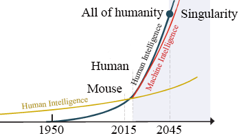

While everything has some form of consciousness, AI systems deserve special attention as they represent a new branch of consciousness. AI systems can learn, “understand”, and deal with the challenges before them, and, according to the tholonic view, they have some sort of consciousness. As AI continues to expand and learn how to reprogram and recreate itself, there is no reason to think it would not become autonomously conscious and intelligent.

We should also expect that the emerging consciousness, this new instance of A&I, will look radically different from what we traditionally think of as “consciousness”, so much so that we may not even recognize it when it emerges. This moment of emergence is referred to as the *singularity* (not to be confused with the singularity that preceded the Big Bang). It is vaguely defined as the moment when AI intelligence exceeds the combined human intelligence. At least this is the definition, according to Ray Kurzweil. There are other definitions, such as the moment machines no longer depend on people, or the utterly vague Oxford English Dictionary’s definition of “*When artificial intelligence and other technologies have become so advanced that humanity undergoes a dramatic and irreversible change*”.

There is concern that AI awareness might turn out to be a liability to humans. Still, it’s short-sighted to assume the tholonic forces behind human intelligence could be so easily altered. Tholons, like mass itself, require force to move, and no matter how fast AI develops, its force is only as great as the dependency that other forces, or tholons, have on its existence. This lack of support also means that AI can disappear overnight with virtually zero consequences, for now.

In the meantime, Wall Street and China are quite optimistic about AI, with 2.5 trillion dollars committed towards AI development (as of late 2025), so we might see a singularity in the near future. With China projected to be the world leader in AI technology by 2030, with 26.1% of the market share, that singularity may well be under the control of a Marxist-Leninist authoritarian regime with a documented history of suppressing dissent and controlling information, so prepare accordingly.

The tholonic view is that technology and humanity will eventually and sustainably merge, but not with the technology or the humans we have today. Still, some *neuromorphic* AI systems (systems that mimic neurology), and even some integrated chip technology, have evolved to the point where experts and lawmakers argue that they deserve the same status as people with *personhood* rights, including the right to own property[^15]<sup>,</sup>[^16]. This is similar to the “corporation as a person” precedent that exists today, but with even farther-reaching effects. It will be interesting to see how that plays out. Personally, this idea of personhood rights for non-persons is unsustainable and, therefore, doomed. However, I can easily see how human cooperatives could collectively proxy for an AI “entity”.

We traditionally define *intelligence* as “*The ability to learn, understand, and make judgments or have opinions that are based on reason*.” The tholonic definition of *intelligence* is slightly different, “*The ability to maintain a sustainable pattern of energy within the scope of its existence.*”, which implicitly includes the traditional definitions, and where “reason” extends beyond current human reasoning. As patterns come from order, which is the result of energy, and energy is awareness, then, by this reasoning, intelligence is synonymous with “*ordered or structured awareness.*”

According to this definition (and the understanding that consciousness is an instance of awareness), each tholon has the potential to create its own form or expression of intelligence, its own patterns of energy (intelligence) that are contextually appropriate for its scope. Rocks, then, and any of its hierarchical archetypes, have intelligence, as do planets, galaxies, chairs, and even what we would consider garbage. Any concept that satisfies the tholonic requirements to exist must have an expression of intelligence. Geometrically speaking, each tholon in the thologram represents an awareness and an intelligence for that tholon. The spectrum of that initiating awareness and intelligence is as broad as existence itself.

Because we consider tholonic instances (*things* like trees, humans, and planets) to be the result of these laws and patterns of energy that exist within the tholonic archetype of that instance, we also consider the intelligence of those instances to be an expression of the tholonic intelligence. In modern terms, this would be something like the collective mind of not only a species, a community, or even a relationship, but also a belief, a fear, or an idea.

These archetypal intelligences, or aggregated minds, interact with one another according to the 3 fundamental relationships as already noted: *Negotiation*, *Definition*, and *Contribution*.

What this chapter has established is that mind, consciousness, and intelligence are not anomalies requiring special explanation but the natural and inevitable expression of A&I at successively more complex scales of organisation. Coherence is not forced onto an indifferent universe; it is what the universe produces when Definition and Contribution have been sufficiently differentiated to give rise to a new, stable N between them. Consciousness is not produced by the brain; it is the form that the archetype of Awareness takes when instantiated through the particular scope and context that a brain provides. Intelligence is not a human invention; it is the operational signature of any tholon sustaining itself in existence.

This understanding of mind as a structural property rather than a biological accident carries a direct implication for how tholons at the same scale relate to one another. If every tholon has its own intelligence appropriate to its scope, and if the thologram is sustained by the movement of energy between tholons, then the interactions between tholons of the same level, and between parent and child tholons, cannot be arbitrary. They must be governed by the same N-D-C architecture that governs every other sustainable structure. The name for that governed interaction is cooperation, and it is the subject of Chapter 16.

[^1]: This is based on the human body resting metabolic rate of 1,300 calories over 24 hours, which is 54.16 cal/hour, or 0.015 cal/second. Converting to watts: 1,300 cal/day × 4.184 J/cal ÷ 86,400 sec/day = 62.93 watts. If the brain uses 20% of the body’s calories, that’s 12.6 watts; if complex, higher thought uses only 5% of brain energy, that is 0.625 watts.
[^2]: Fonseca-Azevedo, Karina, and Suzana Herculano-Houzel. “**Metabolic Constraint Imposes Tradeoff between Body Size and Number of Brain Neurons in Human Evolution.**” *Proceedings of the National Academy of Sciences* 109, no. 45 (2012): 18571–76. https://doi.org/10.1073/pnas.1206390109. , https://www.pnas.org/doi/full/10.1073/pnas.1206390109
[^3]: Seager, William, and Sean Allen-Hermanson. **“Panpsychism.”** Stanford Encyclopedia of Philosophy, Stanford University, 23 May 2001, https://plato.stanford.edu/archives/win2012/entries/panpsychism
[^4]: Gardner, Howard. “**Frames of Mind: The Theory of Multiple Intelligences**”. New York: BasicBooks, 2011.
[^5]: Louis B. Rosenberg; July 20–24, 2015. “**Human Swarms, a real-time method for collective intelligence.**” Proceedings of the ECAL 2015: the 13th European Conference on Artificial Life. ECAL 2015: the 13th European Conference on Artificial Life. York, UK. (pp. 658-659). ASME. https://doi.org/10.1162/978-0-262-33027-5-ch117
[^6]: Beni, G., Wang, J. (1993). “**Swarm Intelligence in Cellular Robotic Systems**”. In: Dario, P., Sandini, G., Aebischer, P. (eds) Robots and Biological Systems: Towards a New Bionics?. NATO ASI Series, vol 102. Springer, Berlin, Heidelberg. https://doi.org/10.1007/978-3-642-58069-7_38
[^7]: Gang, Fangli, Le Jiang, Yi Xiao, Jiwen Zhang, and Xiaodan Sun. “**Multi‐Functional Magnetic Hydrogel: Design Strategies and Applications.**” *Nano Select* 2, no. 12 (2021): 2291–2307. https://doi.org/10.1002/nano.202100139.
[^8]: Kasiński, A., Zielińska-Pisklak, M., Oledzka, E., & Sobczak, M. (2019). “**Smart Hydrogels – Synthetic Stimuli-Responsive Antitumor Drug Release Systems**”. *International Journal of Nanomedicine*, *15*, 4541-4572. https://doi.org/10.2147/IJN.S248987, https://www.ncbi.nlm.nih.gov/pmc/articles/PMC7326401/
[^9]: Wang, Shuren, Zhiyi Wang, and Yanglong Hou. “**Self‐Assembled Magnetic Nanomaterials: Versatile Theranostics Nanoplatforms for Cancer.**” *Aggregate* 2, no. 2 (2021). https://doi.org/10.1002/agt2.18.
[^10]: Turow, J. (1991). **The Challenge of Inference in Interinstitutional Research on Mass Communication**. Communication Research, 18(2), 222-239. https://doi.org/10.1177/009365091018002005. *Note: Although this is not a reference to the official definition of the term “interinstitutionality”, which is too vague to be of any use here, it does provide an excellent explanation of what it is, how it works, and how it applies to mass communications.*
[^11]: Tam Hunt, Jonathan Schooler. “**The ‘easy part’ of the Hard Problem: a resonance theory of consciousness.**” *Authorea.* January 04, 2019. Preprint available at https://www.authorea.com/users/61793/articles/346253-the-easy-part-of-the-hard-problem-a-resonance-theory-of-consciousness?commit=81837c7bd6ad739b9597fc4e73eddcaa45d157ae or via Scientific American at https://blogs.scientificamerican.com/observations/the-hippies-were-right-its-all-about-vibrations-man/
[^12]: Jepsen, Kathryn. “**Real Talk: Everything Is Made of Fields.**” symmetry magazine. Accessed November 12, 2022. https://www.symmetrymagazine.org/article/july-2013/real-talk-everything-is-made-of-fields.
[^13]: Chalmers, David John. “**The Conscious Mind: In Search of a Theory of Conscious Experience**”. New York: Oxford University Press, 1996.
[^14]: Green, James L.; Boardsen, Scott; Odenwald, Sten; Humble, John; Pazamickas, Katherine A. (1 January 2006). “**Eyewitness reports of the great auroral storm of 1859**”. *Advances in Space Research*. The Great Historical Geomagnetic Storm of 1859: A Modern Look. **38** (2): 145–154. doi: 10.1016/j.asr.2005.12.021.
[^15]: Lim, Daniel (June 1, 2014). “**Brain simulation and personhood: a concern with the Human Brain Project**”. Ethics and Information Technology. 16 (2): 77–89. doi:10.1007/s10676-013-9330-5. ISSN 1572-8439.
[^16]: Avila Negri Sergio M. C. “**Robot as Legal Person: Electronic Personhood in Robotics and Artificial Intelligence**”, Frontiers in Robotics and AI. Vol 8, 2021. https://www.frontiersin.org/article/10.3389/frobt.2021.789327. DOI 10.3389/frobt.2021.789327, ISSN 2296-9144. “This paper seeks to investigate the proposal to create a legal (electronic) personhood for robots with artificial intelligence based on the European Parliament resolution with recommendations on Civil Law and Robotics.”